# Homework 10

Solutions for Questions 1 and 2 will be available after Monday, November 2, 2026. No solution will be provided for Question 3.

Use the RLT package for Questions 1 and 2: `RLT` in R or `rlt` in Python. The node-size parameter is `nmin` in R and `min_samples_leaf` in Python; both stop splitting a node when it contains at most that many observations. The candidate-predictor parameter is `mtry` in both languages. Use ordinary random forests, with reinforcement turned off.

## Question 1: Bias-variance trade-off simulation

Two important tuning parameters of random forests are node size and `mtry`. We have performed some preliminary analysis in class. The goal of this question is to perform a larger simulation study for these two tuning parameters.

Consider a regression model with five jointly normally distributed predictors. Each predictor has mean 0 and variance 1, and the correlation between any two different predictors is 0.3. The response is

$$Y=X_1+X_3+X_5+\varepsilon,
\qquad \varepsilon\sim N(0,1),$$

where the noise is independent of the predictors. Thus the true regression function is $f(\mathbf{x})=x_1+x_3+x_5$.

1. Set up a simulation study with 100 repetitions. Generate 200 test predictor vectors once and keep them fixed. In each repetition, generate 200 new training observations and use the same training data for all tuning settings. Fit 500-tree forests, drawing 200 observations with replacement for each tree. Make the following two comparisons:
   - Fix `mtry` at 3 and vary node size over $1,5,10,20,30$.
   - Fix node size at 10 and vary `mtry` over $1,2,3,4,5$.

   Leave all other fitting parameters at their defaults. Record the predictions at each test point across repetitions. For each setting, estimate the squared bias and variance at each test point, then average them over the 200 test points. Compare predictions with $f(\mathbf{x})$ when estimating bias. Produce two figures, one for each tuning parameter, showing the averaged squared bias and variance. Set a random seed and report it.

$$Bias(Y) = E(\hat{Y}) - Y = \mu_Y - Y \qquad Variance(Y) = E(X^2) - E(X)^2$$

**Show the workflow**

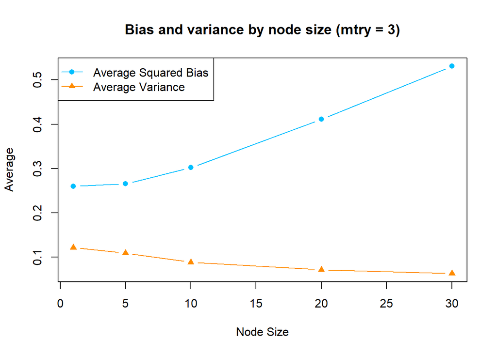

```r
library(RLT)
set.seed(43201)

# Generate 200 test predictor vectors
x1 <- rnorm(n = 200, mean = 0, sd = 1)
x2 <- rnorm(n = 200, mean = 0, sd = 1)
x3 <- rnorm(n = 200, mean = 0, sd = 1)
x4 <- rnorm(n = 200, mean = 0, sd = 1)
x5 <- rnorm(n = 200, mean = 0, sd = 1)

e <- rnorm(n = 200, mean = 0, sd = 1)
cor_matrix <- matrix(0.3, nrow = 5, ncol = 5)
diag(cor_matrix) <- 1

Z_test <- cbind(x1, x2, x3, x4, x5)
X_test <- Z_test %*% chol(cor_matrix)
f_test <- X_test[, 1] + X_test[, 3] + X_test[, 5]

# Set up the node grids for mtry = 3
node_grid <- c(1, 5, 10, 20, 30)

# Set up parameters
nsim <- 100

# test point x repetition x node size; 200 x 100 x 5
pred1 <- array(NA_real_, dim = c(200, nsim, length(node_grid)))

# Run the simulation 100 times
for (r in 1:nsim){

  # Generate the training data for each run
  Z_train <- matrix(rnorm(200 * 5), nrow = 200, ncol = 5)
  X_train <- Z_train %*% chol(cor_matrix)

  e_train <- rnorm(n = 200, mean = 0, sd = 1)
  y_train <- X_train[, 1] + X_train[, 3] + X_train[, 5] + e_train

  # Run the simulation at each node size for mtry = 3
  for (i in seq_along(node_grid)){

    # Fit 500-tree forest for each node size
    fit <- RLT(X_train, y_train,
               model = "regression",
               ntrees = 500,
               mtry = 3,
               nmin = node_grid[i],
               resample.prob = 1,
               replacement = TRUE
               )

    # Record the predictions at each test point across repetitions
    pred1[, r, i] <- predict(fit, X_test)$Prediction

  }
}

# Estimate the squared bias and variance at each test point
mean_pred1 <- apply(pred1, c(1, 3), mean)
squared_bias1 <- (mean_pred1 - f_test)^2
variance1 <- apply(pred1, c(1, 3), var)

# Average squared bias and variance over the 200 test points
avg_squared_bias1 <- colMeans(squared_bias1)
avg_variance1 <- colMeans(variance1)

# Repeat simulation for node size = 10
mtry_grid <- c(1, 2, 3, 4, 5)
pred2 <- array(NA_real_, dim = c(200, nsim, length(mtry_grid)))

# Run the simulation 100 times
for (r in 1:nsim){

  # Generate the training data for each run
  Z_train <- matrix(rnorm(200 * 5), nrow = 200, ncol = 5)
  X_train <- Z_train %*% chol(cor_matrix)

  e_train <- rnorm(n = 200, mean = 0, sd = 1)
  y_train <- X_train[, 1] + X_train[, 3] + X_train[, 5] + e_train

  # Run the simulation at each mtry for node size = 10
  for (i in seq_along(mtry_grid)){

    # Fit 500-tree forest for each mtry
    fit <- RLT(X_train, y_train,
               model = "regression",
               ntrees = 500,
               mtry = mtry_grid[i],
               nmin = 10,
               resample.prob = 1,
               replacement = TRUE
    )

    # Record the predictions at each test point across repetitions
    pred2[, r, i] <- predict(fit, X_test)$Prediction

  }
}

# Estimate the squared bias and variance at each test point
mean_pred2 <- apply(pred2, c(1, 3), mean)
squared_bias2 <- (mean_pred2 - f_test)^2
variance2 <- apply(pred2, c(1, 3), var)

# Average squared bias and variance over the 200 test points
avg_squared_bias2 <- colMeans(squared_bias2)
avg_variance2 <- colMeans(variance2)

# Plot figures for tuning parameters node size and mtry
# node size
plot(x = node_grid, y = avg_squared_bias1,
     ylim = range(c(avg_squared_bias1, avg_variance1)),
     main = "Bias and variance by node size (mtry = 3)",
     xlab = "Node Size", ylab = "Average",
     type = "b", pch = 16, col = "deepskyblue"
     )
lines(x = node_grid, y = avg_variance1,
      type = "b", pch = 17, col = "darkorange")
legend(
  "topleft",
  legend = c("Average Squared Bias", "Average Variance"),
  col = c("deepskyblue", "darkorange"),
  pch = c(16, 17),
  lty = 1
)
```

**Show the workflow**

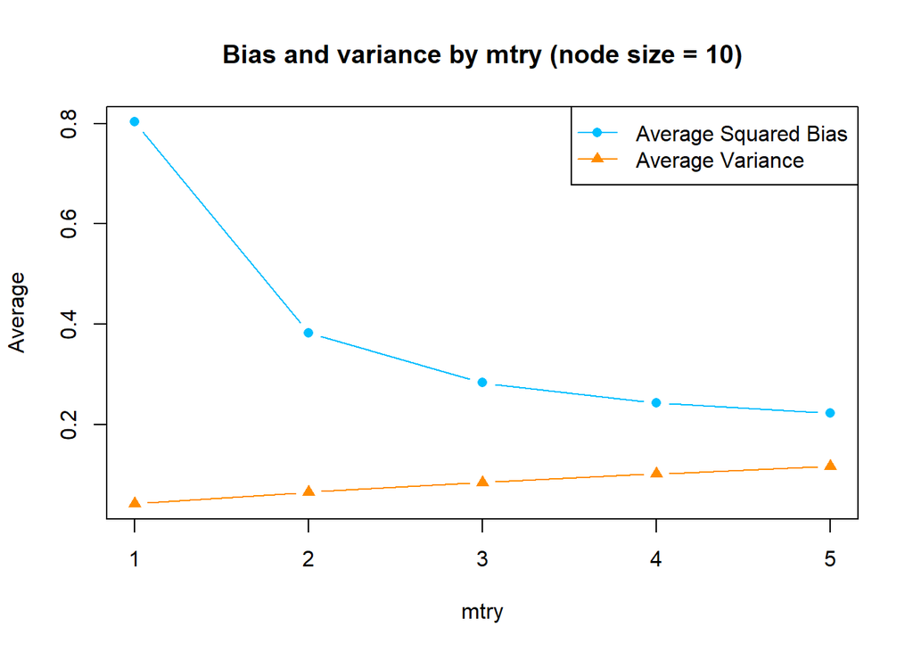

```r
# mtry
plot(x = mtry_grid, y = avg_squared_bias2,
     ylim = range(c(avg_squared_bias2, avg_variance2)),
     main = "Bias and variance by mtry (node size = 10)",
     xlab = "mtry", ylab = "Average",
     type = "b", pch = 16, col = "deepskyblue"
)
lines(x = mtry_grid, y = avg_variance2,
      type = "b", pch = 17, col = "darkorange")
legend(
  "topright",
  legend = c("Average Squared Bias", "Average Variance"),
  col = c("deepskyblue", "darkorange"),
  pch = c(16, 17),
  lty = 1
)
```

2. Discuss your results in terms of the bias-variance trade-off:
   - How does a large node size, such as 30, affect the fit in this example?
   - What are the benefits and drawbacks of using a large `mtry` value?
   - If each tree instead sampled 100 observations with replacement, would you expect the preferred node size to shift toward smaller or larger values? Explain your reasoning. You may use an additional simulation to help, but a particular pattern is not guaranteed.

At large node sizes, the average variance is close to 0 whereas the average squared bias has increased significantly. “A small terminal node uses few observations to form its prediction. This resembles the small-𝑘 choice in KNN: it allows a more local fit, but the prediction can be more variable. Large terminal nodes average over more observations and can miss local structure” (Week 10 Lecture: Random Forests and Tuning).

Using a large mtry value increases the average variance but significantly decreases the average squared bias. “With a small mtry, a split may have only irrelevant predictors to choose from. Missing the useful predictors can increase bias. A larger mtry makes the search more greedy: more predictors compete, and the strongest available split wins. This can improve individual trees, but it can also make trees more alike” (Week 10 Lecture: Random Forests and Tuning).

If each tree sampled 100 observations with replacement, I would expect the preferred node size to shift toward larger values. This is because less observations with replacement means each tree has less information to create its splits. Less information means smaller node sizes would make the predictions unstable. Therefore, having a larger node size would help make the predictions more stable and reduce variance, but bias will increase.

## Question 2: Tuning random forests for MNIST

Use `mnist-first2000.csv.gz` from the combined ZIP. It contains 2,000 MNIST observations, with the digit label `Digit` and 784 pixel values.

- From the first 1,000 observations, keep digits 1, 6, and 7 as the training data. From the remaining 1,000 observations, keep the same digits as the test data.
- Fit PCA to the training pixels, centering but not scaling them. Use the first 20 principal components as predictors, and project the test observations using the same training means and loadings.

Complete the following tasks using RLT classification forests with 1,000 trees. For each tree, draw a bootstrap sample of the same size as the training set.

1. Fit a random forest with the default `mtry` and node-size settings. Report the out-of-bag (OOB) misclassification rate.

According to Week 10: Random Forests and Tuning, to calculate out-of-bag (OOB) misclassification rate:

i. Fit the trees and keep track of which observations were left out of each sample.

ii. For each observation, average predictions from its OOB trees.

iii. Compare the OOB prediction with the observed response and average the losses.

“For regression, the resulting average squared error is the OOB MSE” (Week 10: Random Forests and Tuning).

**Show the workflow**

```r
# Load the file
df_mnist <- read.csv("data/mnist-first2000.csv.gz")

# From the first 1,000 observations, keep digits 1, 6, and 7 as training data
# %in% checks if number exists in the dataframe
train_mnist <- subset(df_mnist[1:1000, ], Digit %in% c(1, 6, 7))
pixel_train <- train_mnist[, -1]
y_train <- train_mnist$Digit

# From the second 1,000 observations, keep the same digits as test data
test_mnist <- subset(df_mnist[1001:2000, ], Digit %in% c(1, 6, 7))
pixel_test <- test_mnist[, -1]
y_test <- test_mnist$Digit

# Fit PCA to training pixels (center but don't scale)
# prcomp() performs principal component analysis
pixel_pca <- prcomp(pixel_train, center = TRUE, scale = FALSE)

# Use the first 20 PCs as predictors
X_train <- pixel_pca$x[, 1:20, drop = FALSE]

# Project test observations using the same training means and loadings
# Grab only the first 20 PCs
X_test <- predict(pixel_pca, newdata = pixel_test)[, 1:20, drop = FALSE]

# Fit a random forest with classification, 1000 trees, and default mtry and node-size settings
pixel_fit <- RLT(X_train, factor(y_train),
                 model = "classification",
                 ntrees = 1000,
                 resample.prob = 1,
                 replacement = TRUE,
                 track.obs = TRUE
)

# Create a function to calculate OOB misclassification rate
oob_error <- function(fit, X, y){

  # Get per-tree predictions and identify OOB trees
  tree_prob <- predict(fit, X)$AllPrediction
  oob_tree <- fit$ObsTrack == 0

  # Create an emptry matrix to store averaged probabilities
  class_levels <- levels(factor(y)) # Digits 1, 6, 7
  oob_prob <- matrix(NA_real_,
                     nrow = nrow(X),
                     ncol = length(class_levels),
                     dimnames = list(NULL, class_levels)
  ) # One row per observation and one column per class

  # For each observation, average predictions from its OOB trees
  for (i in seq_len(nrow(X))){

    # Find the trees that were left out
    oob_trees <- which(oob_tree[i, ])

    if(length(oob_trees) == 0L){
      stop("An observation has no OOB trees.")
    }

    # Average the class probabilities from the selected trees
    oob_prob[i, ] <- colMeans(do.call(
      rbind,
      lapply(oob_trees, function(b) tree_prob[[b]][i, ])
    ))
  }

  # Choose the class with the highest average probability
  oob_pred <- factor(
    class_levels[max.col(oob_prob, ties.method = "first")],
    levels = class_levels
  )

  # Calculate the fraction of OOB predictions that were wrong
  mean(oob_pred != factor(y, levels = class_levels))

}

oob_rate <- oob_error(pixel_fit, X_train, y_train)
paste("The out-of-bag (OOB) misclassification rate is",
      round(oob_rate, digits = 5))
```

```
[1] "The out-of-bag (OOB) misclassification rate is 0.03058"
```

2. Construct a grid of `mtry` and node-size values to tune the model. Select the setting using OOB misclassification rate. Report the OOB error for each setting and the selected values. Calculate and present the selected forest’s OOB permutation variable importance for the 20 principal components. Comment on your results.

**Show the workflow**

```r
# Construct a grid of mtry and node-size (aka nmin) values
alltune <- expand.grid(nmin = seq(from = 5, to = 20, by = 5),
                       mtry = seq(from = 5, to = 20, by = 5)
                       )
allerror <- numeric(nrow(alltune))

for (k in 1:nrow(alltune)){
  fit <- RLT(X_train, factor(y_train),
             model = "classification",
             ntrees = 1000,
             nmin = alltune$nmin[k],
             mtry = alltune$mtry[k],
             resample.prob = 1,
             replacement = TRUE,
             track.obs = TRUE
             )

  # Calculate OOB misclassification rate for each setting
  allerror[k] <- oob_error(fit, X_train, y_train)

}

results <- cbind(
  alltune,
  OOB_misclassification_rate = round(allerror, digits = 5)
  )
results
```

```
   nmin mtry OOB_misclassification_rate
1     5    5                    0.02141
2    10    5                    0.03058
3    15    5                    0.03364
4    20    5                    0.03670
5     5   10                    0.03364
6    10   10                    0.03976
7    15   10                    0.04281
8    20   10                    0.04587
9     5   15                    0.03670
10   10   15                    0.03670
11   15   15                    0.04587
12   20   15                    0.04893
13    5   20                    0.03364
14   10   20                    0.03670
15   15   20                    0.03976
16   20   20                    0.03976
```

**Show the workflow**

```r
# Calculate the selected forest's OOB permutation variable importance for the 20 PCs
# mtry = 5, nmin = 5
vi_fit <- RLT(X_train, factor(y_train),
              model = "classification",
              ntrees = 1000,
              nmin = 5,
              mtry = 5,
              resample.prob = 1,
              replacement = TRUE,
              importance = TRUE,
              track.obs = TRUE
)

vi_results <- data.frame(
  PC = colnames(X_train),
  vi = round(as.numeric(vi_fit$VarImp), digits = 4)
)
vi_results
```

```
     PC     vi
1   PC1 0.8376
2   PC2 1.3393
3   PC3 0.1607
4   PC4 0.0723
5   PC5 0.1515
6   PC6 0.1377
7   PC7 0.0768
8   PC8 0.0459
9   PC9 0.0364
10 PC10 0.0545
11 PC11 0.0809
12 PC12 0.0544
13 PC13 0.0374
14 PC14 0.0407
15 PC15 0.0242
16 PC16 0.0479
17 PC17 0.0362
18 PC18 0.0626
19 PC19 0.0275
20 PC20 0.0372
```

In general, smaller mtry values have lower OOB misclassification rates. `mtry` = 5 and `nmin` = 5 has the lowest OOB misclassification rates of any candidate settings. The error rates tend to increase at higher node sizes.

PC1 and PC2 have the largest importance values for the candidate setting. This suggests that the fitted forests rely more on the first two principal components than the rest of the 18 components for classification. “Permutation importance describes predictive reliance in this fitted model. It does not establish a causal effect, and correlated predictors can share importance” (Week 10: Random Forests and Tuning).

3. Apply the selected model to the test data and report the misclassification rate and confusion matrix. Use the test labels only for this final assessment.

**Show the workflow**

```r
# mtry = 5, nmin = 5
test_fit <- RLT(X_train, factor(y_train),
           model = "classification",
           ntrees = 1000,
           nmin = 5,
           mtry = 5,
           resample.prob = 1,
           replacement = TRUE,
           track.obs = TRUE
)

class_levels <- levels(factor(y_train)) # Digits 1, 6, 7

# Predict the test observations
test_pred <- predict(test_fit, X_test)$Prediction

# Transform RLT predictions 0, 1, 2 to 1, 6, 7
test_pred_labels <- factor(
  class_levels[as.integer(test_pred) + 1L],
  levels = class_levels)

# Convert actual test labels to a factor with the same levels
y_test_factor <- factor(y_test, levels = class_levels)

# Calculate the misclassification rates for the test data
test_rate <- mean(test_pred_labels != y_test_factor)

# Report misclassification rates and confusion matrices
cm <- table(Actual = y_test_factor, Predicted = test_pred_labels)

test_results <- data.frame(
  mtry = 5,
  nmin = 5,
  test_misclassification_rate = test_rate
  )

test_results
```

```
  mtry nmin test_misclassification_rate
1    5    5                  0.01577287
```

**Show the workflow**

```r
cm
```

```
      Predicted
Actual   1   6   7
     1 102   0   2
     6   1 105   0
     7   1   1 105
```

## Question 3: Planning a random-forest analysis skill

In earlier homework, some students wrote long skill files with detailed instructions, while others wrote short skills emphasizing their specific requirements or references. These approaches may perform differently depending on the AI and the task. A capable AI may already know standard ways to perform an analysis, so some instructions may be redundant, add little value, or sometimes make the analysis worse. It may be more useful to specify your personal choices for the analysis. An AI with more limited knowledge may benefit from detailed instructions that remind it of the steps to perform.

1. Write one paragraph describing how you would write a skill that directs an AI to perform a random-forest analysis and produce a report for a future dataset. Discuss how you would balance standard analysis instructions with your personal preferences, considering the AI’s capabilities.

   I would instruct the AI to not perform the skill unless explicitly told to do so. For the analysis, I would instruct the AI to check if the dataset is suitable for a random-forest analysis, tune the parameters using an appropriate method, and evaluate the model’s performance on the selected tuned parameters. I would not overly explain the methods for tuning and validation, but I would give enough information so that the AI could perform the analysis for any dataset. In addition, I would instruct the AI to explain its procedure and state any limitations.
2. Provide **10 instructions** you would consider including in the skill, **ordered from the most basic instructions to the more personal preferences**. Your list may cover computation, tuning, tables, figures, interpretation, presentation, or other aspects of a random-forest report.
   1. Use this workflow only when the user explicitly invokes this skill and supplies the dataset, response, and predictors. Do not assume variable names, class count, coding, or results. Ask for missing inputs before analysis.
   2. Identify the response and predictors. Check for missing/non-numeric predictors. Determine if the data are suitable for a random-forest analysis.
   3. Set and report a random seed. Identify tuning parameters and use grid search.
   4. Use cross-validation to test the tuned parameters.
   5. Produce a figure with average squared bias and average variance for each tuning parameter.
   6. Produce a table with candidate settings, their average CV errors, and the selected model.
   7. A brief description of candidates and CV procedure, the selection, main findings, and limitations.
   8. Interpretation of the fit and key numerical results. Explain why.
   9. Add background information about the dataset and state any variables used.
   10. Produce a one-page report with 11-point font.

You only need to discuss how the skill should be written. You are not required to write a complete skill file or test it.